# Proteomic consistency metrics – Development Version with static metrics

Simina Boca, Shaojun Tang, Yi Bai, Nathan Edwards

July 13, 2017

## Number of MS2 spectra

### Per sample, across fraction (boxplot)

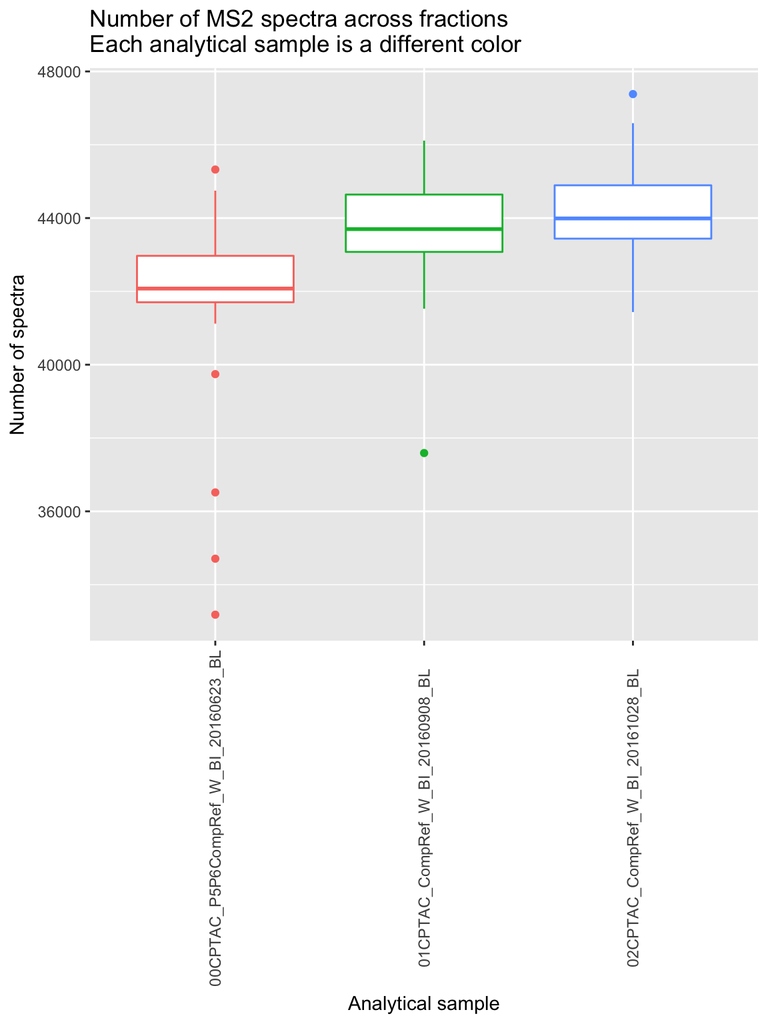

Back to top

### Per sample, versus fraction (scatterplot)

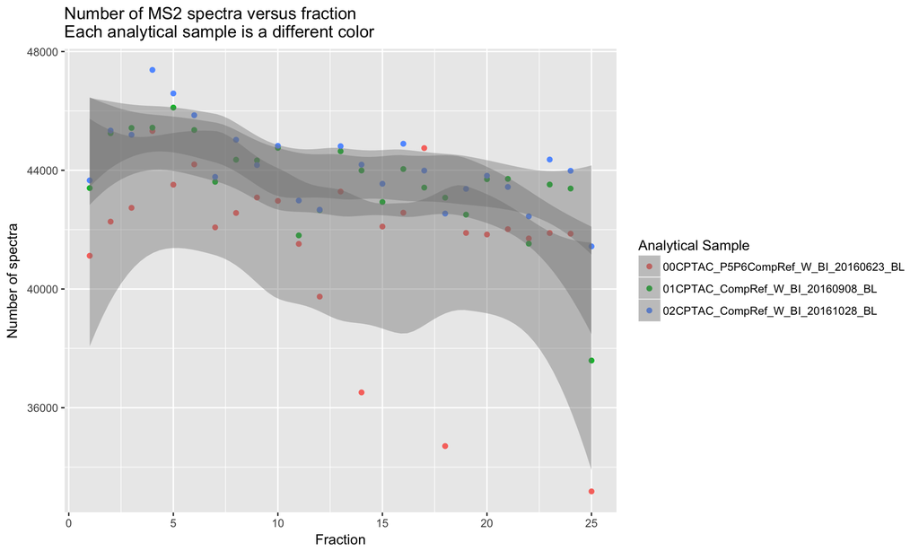

Back to top

### Number of MS2 spectra versus fraction (boxplot)

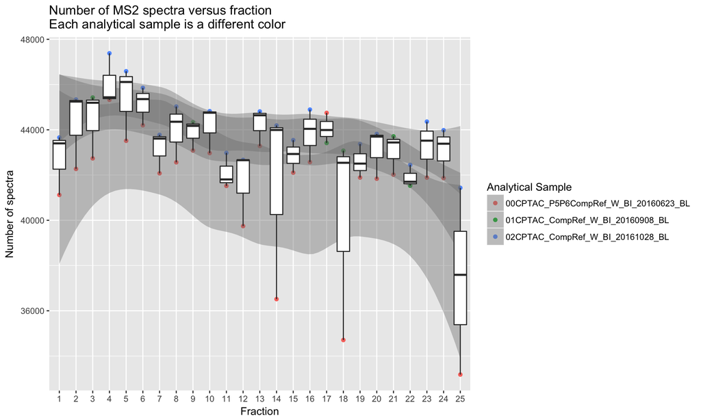

Back to top

## Precursor intensity values

### Range of Precursor intensity values

This table shows the range of the precursor intensity for each percentile, as a summary and to see if there are any value of 0 that cannot be log-trnasformed.

|  | 5th Perc | 25th perc | 50th perc | 75th perc | 95th perc |
| --- | --- | --- | --- | --- | --- |
| range | 0, 0 | 13921.04, 2785124.75 | 50261.56, 8182241.5 | 140378.73, 20557060 | 1450821.96, 86219475.2 |
| range of log10 transformed | -Inf, -Inf | 4.14, 6.44 | 4.7, 6.91 | 5.15, 7.31 | 6.16, 7.94 |

Back to top

### Per sample, versus fraction (scatterplot)

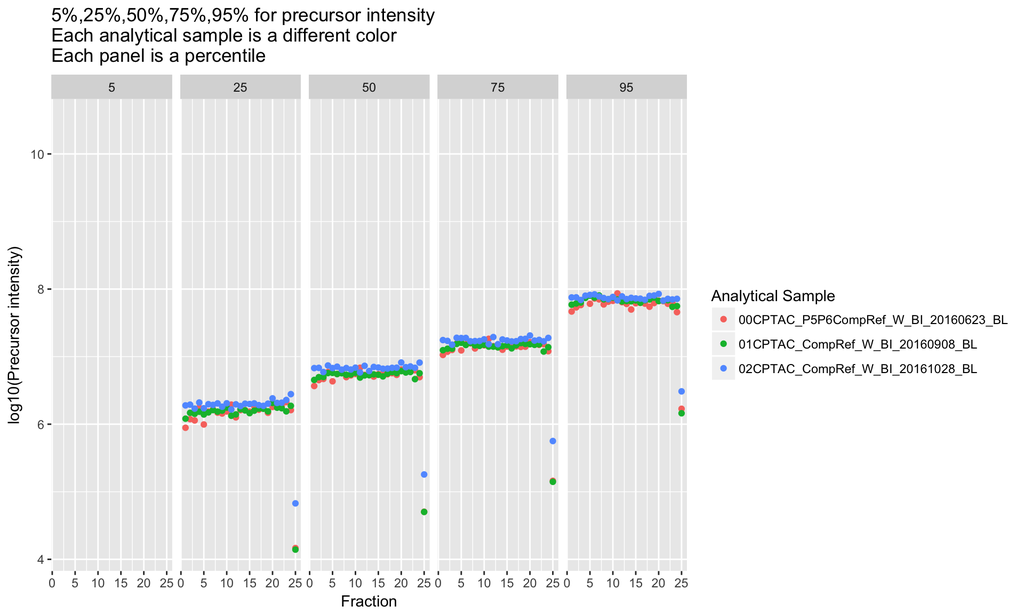

Back to top

### Percentage of 0 precursor intensities at different percentiles

In this table, each row represents a fraction and each column represents a percentile. Each value represents the percent of samples that have a precursor intensity of 0 at that fraction and that percentile.

|  | 5th Perc | 25th Perc | 50th Perc | 75th Perc | 95th Perc |
| --- | --- | --- | --- | --- | --- |
| fraction1 | 100 | 0 | 0 | 0 | 0 |
| fraction2 | 100 | 0 | 0 | 0 | 0 |
| fraction3 | 100 | 0 | 0 | 0 | 0 |
| fraction4 | 100 | 0 | 0 | 0 | 0 |
| fraction5 | 100 | 0 | 0 | 0 | 0 |
| fraction6 | 100 | 0 | 0 | 0 | 0 |
| fraction7 | 100 | 0 | 0 | 0 | 0 |
| fraction8 | 100 | 0 | 0 | 0 | 0 |
| fraction9 | 100 | 0 | 0 | 0 | 0 |
| fraction10 | 100 | 0 | 0 | 0 | 0 |
| fraction11 | 100 | 0 | 0 | 0 | 0 |
| fraction12 | 100 | 0 | 0 | 0 | 0 |
| fraction13 | 100 | 0 | 0 | 0 | 0 |
| fraction14 | 100 | 0 | 0 | 0 | 0 |
| fraction15 | 100 | 0 | 0 | 0 | 0 |
| fraction16 | 100 | 0 | 0 | 0 | 0 |
| fraction17 | 100 | 0 | 0 | 0 | 0 |
| fraction18 | 100 | 0 | 0 | 0 | 0 |
| fraction19 | 100 | 0 | 0 | 0 | 0 |
| fraction20 | 100 | 0 | 0 | 0 | 0 |
| fraction21 | 100 | 0 | 0 | 0 | 0 |
| fraction22 | 100 | 0 | 0 | 0 | 0 |
| fraction23 | 100 | 0 | 0 | 0 | 0 |
| fraction24 | 100 | 0 | 0 | 0 | 0 |
| fraction25 | 100 | 0 | 0 | 0 | 0 |

Back to top

## Precursor m/z values

### Per sample, versus fraction (scatterplot)

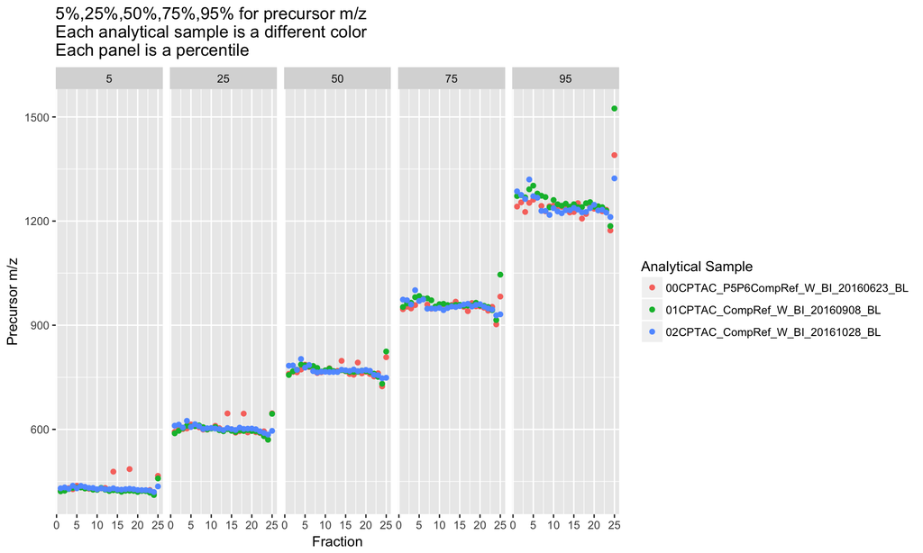

Back to top

## Precursor Molecular weight (MW) values

### Per sample, versus fraction (scatterplot)

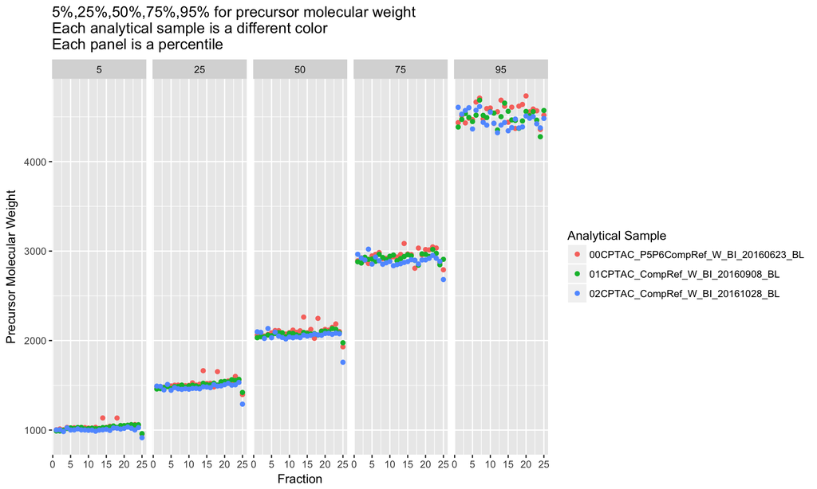

Back to top

### Per sample, across fraction at 50 percentile (boxplot)

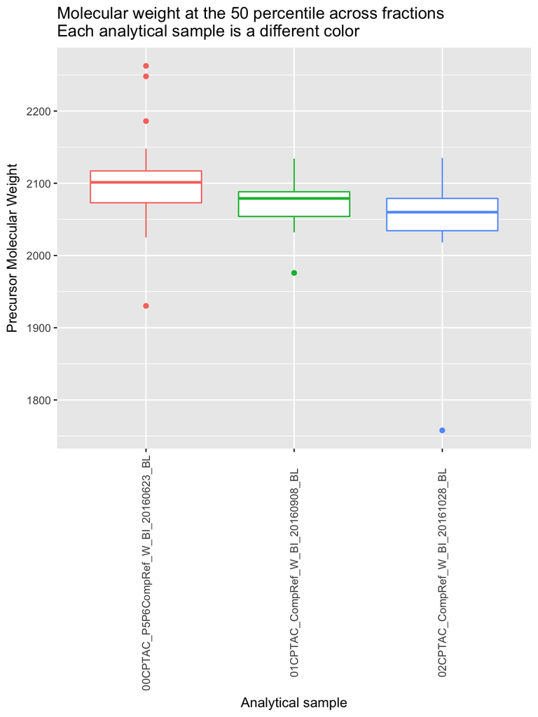

Back to top

### Per sample, across fraction (boxplot)

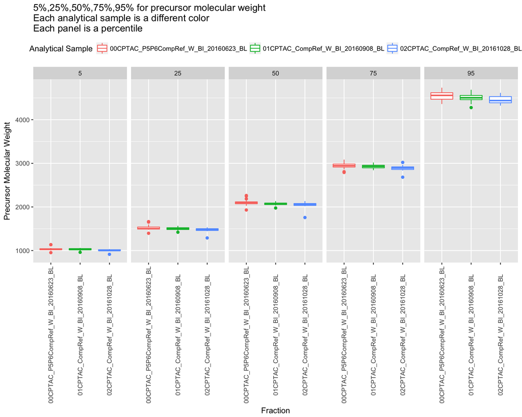

Back to top

## MS2 per MS values

### Per sample, versus fraction (scatterplot)

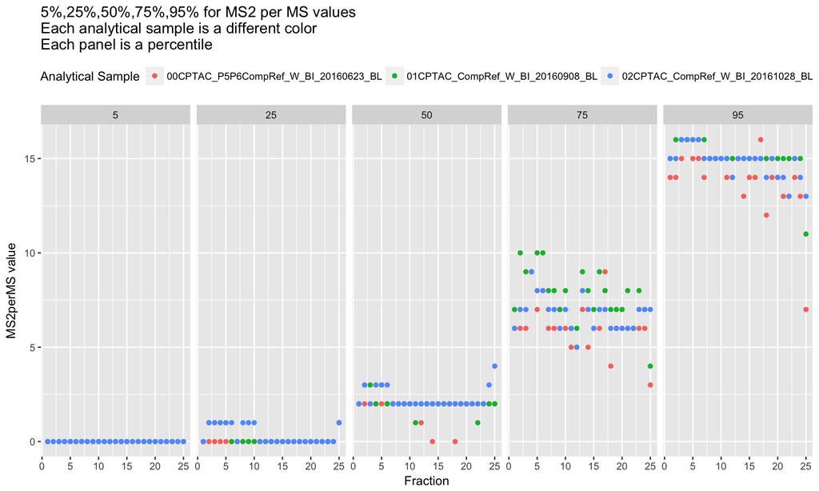

Back to top

## Different MS2 charge state to MS2 charge 2 ratio

### Per sample, versus fraction (scatterplot)

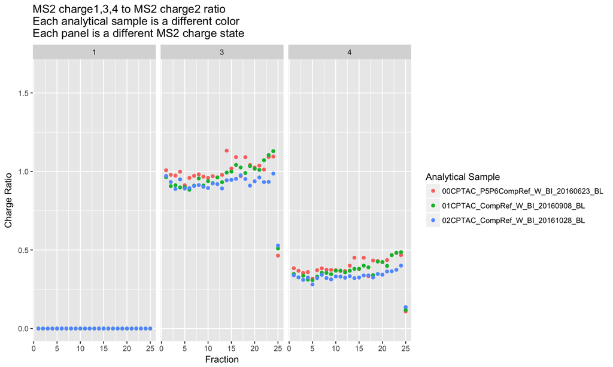

Back to top

## Data file

We used the “Compref_BI_Proteome_QCmetrics.tsv” data file in this report. To see the data file in tsv format, please click **Here**

Back to top

## PDF file

To generate the PDF file of this report please run the following code in the R command line “rmarkdown::render(”./developed_version_static_7:5.Rmd“, output_format=”pdf_document“)” To view the generated PDF file, please click **Here**

Back to top